# Gibbs Sampling: Salamander

Author

Jiachen Ai; UID: 206182615

Published

December 9, 2024

## Problem Statement

You are tasked with analyzing customer satisfaction for a small bakery. The bakery owner believes that customer satisfaction $y$ is influenced by the quality of the pastries, which varies daily. Let $y \sim N(\mu, \sigma^2)$, where $\mu$ represents the average satisfaction score and $\sigma^2$ is the variance. However, the bakery owner is unsure about $\mu$ and $\sigma^2$. The owner believes that the satisfaction is generally around 5 but uncertain.

To model this uncertainty:

- Assume $\mu \sim N(\mu_0=5, \tau^2=4)$, reflecting that satisfaction scores are typically around 5.
- Assume $\sigma^2 \sim \text{Inverse-Gamma}(\alpha=2, \beta=3)$, based on historical variability.

### Task

- Estimate the posterior mean and variance of $\mu$.
- Use the following satisfaction scores from 10 customers: $\{6, 7, 5, 4, 6, 7, 5, 5, 6, 4\}$.
- Run 1,000 iterations of the Gibbs sampler and report the posterior mean of $\mu$.

## Problem Setup

### Model

Customer satisfaction scores ($y$) are modeled as: $y \sim N(\mu, \sigma^2)$, where $\mu$ represents the average satisfaction score and $\sigma^2$ is the variance.

#### Priors

- $\mu \sim N(\mu_0=5, \tau^2=4)$
- $\sigma^2 \sim \text{Inverse-Gamma}(\alpha=2, \beta=3)$

#### Data

$y = \{6, 7, 5, 4, 6, 7, 5, 5, 6, 4\}$

### Bayesian Approach

#### Posterior Distribution

Given the data and priors, the posterior distribution of $\mu$ and $\sigma^2$ is proportional to the likelihood times the prior:

$$p(\mu, \sigma^2 | y) \propto p(y | \mu, \sigma^2) p(\mu) p(\sigma^2)$$

, where

- $p(y | \mu, \sigma^2)$ is the likelihood of the data given $\mu$ and $\sigma^2$.
- $p(\mu)$ is the prior distribution of $\mu$.
- $p(\sigma^2)$ is the prior distribution of $\sigma^2$.

### Conditional Distributions for Gibbs Sampling

To sample from the joint posterior, we use the following conditional distributions:

- $\mu | \sigma^2, y \sim N(\mu_n, \tau_n^2)$, where:

$$\tau_n^2 = \left(\frac{1}{\tau^2} + \frac{n}{\sigma^2}\right)^{-1}$$

$$\mu_n = \tau_n^2 \left(\frac{\mu_0}{\tau^2} + \frac{\sum y}{\sigma^2}\right)$$

- $\sigma^2 | \mu, y \sim \text{Inverse-Gamma}(\alpha_n, \beta_n)$, where:

$$\alpha_n = \alpha + \frac{n}{2}$$

$$\beta_n = \beta + \frac{1}{2} \sum (y - \mu)^2$$

### Gibbs Sampling Algorithm:

- Initialize $\mu$ and $\sigma^2$. (e.g., $\mu = 5$ and $\sigma^2 = 1$)
- For each iteration:
  - Sample $\mu$ from $p(\mu | \sigma^2, y)$.
  - Sample $\sigma^2$ from $p(\sigma^2 | \mu, y)$.
- Repeat for a fixed number of iterations (e.g., 1,000).

## Implementation in R

```r
# Data
y <- c(6, 7, 5, 4, 6, 7, 5, 5, 6, 4)
n <- length(y)

# Priors
mu0 <- 5
tau2 <- 4
alpha <- 2
beta <- 3

# Initial values
mu <- 5
sigma2 <- 1

# Number of iterations
nIter <- 1000
mu_samples <- numeric(nIter)
sigma2_samples <- numeric(nIter)

# Gibbs sampler
for (i in 1:nIter) {
  # Update mu
  tau_n2 <- 1 / (n / sigma2 + 1 / tau2)
  mu_n <- tau_n2 * (sum(y) / sigma2 + mu0 / tau2)
  mu <- rnorm(1, mean = mu_n, sd = sqrt(tau_n2))
  mu_samples[i] <- mu

  # Update sigma2
  alpha_n <- alpha + n / 2
  beta_n <- beta + sum((y - mu)^2) / 2
  sigma2 <- 1 / rgamma(1, shape = alpha_n, rate = beta_n)
  sigma2_samples[i] <- sigma2
}

# Discard burn-in
mu_samples <- mu_samples[101:nIter]
sigma2_samples <- sigma2_samples[101:nIter]

# Posterior summaries
posterior_mu_mean <- mean(mu_samples)
posterior_mu_variance <- var(mu_samples)

# Output results
posterior_mu_mean
```

```
[1] 5.469868
```

```r
posterior_mu_variance
```

```
[1] 0.1418079
```

Credible Intervals:

```r
quantile(mu_samples, c(0.025, 0.975))
```

```
    2.5%    97.5%
4.748928 6.269098
```

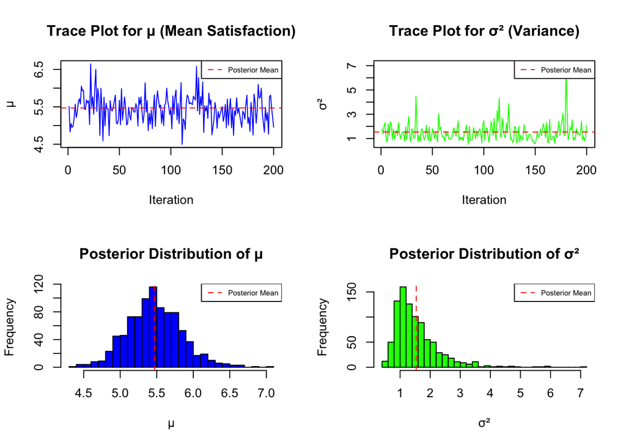

```r
# Posterior Summaries
posterior_mu_mean <- mean(mu_samples)
posterior_mu_variance <- var(mu_samples)
posterior_sigma2_mean <- mean(sigma2_samples)
posterior_sigma2_variance <- var(sigma2_samples)

# Visualization
par(mfrow = c(2, 2))  # Arrange plots in 2x2 grid

# Traceplot for mu
plot(mu_samples[1:200], type = "l", col = "blue", main = "Trace Plot for μ (Mean Satisfaction)",
     xlab = "Iteration", ylab = "μ")
abline(h = posterior_mu_mean, col = "red", lty = 2)
legend("topright", legend = c("Posterior Mean"), col = c("red"), lty = 2, cex = 0.6)

# Traceplot for sigma^2
plot(sigma2_samples[1:200], type = "l", col = "green", main = "Trace Plot for σ² (Variance)",
     xlab = "Iteration", ylab = "σ²")
abline(h = posterior_sigma2_mean, col = "red", lty = 2)
legend("topright", legend = c("Posterior Mean"), col = c("red"), lty = 2, cex = 0.6)

# Histogram for mu
hist(mu_samples, breaks = 30, col = "blue", border = "black", main = "Posterior Distribution of μ",
     xlab = "μ", ylab = "Frequency")
abline(v = posterior_mu_mean, col = "red", lty = 2)
legend("topright", legend = c("Posterior Mean"), col = c("red"), lty = 2, cex = 0.6)

# Histogram for sigma^2
hist(sigma2_samples, breaks = 30, col = "green", border = "black", main = "Posterior Distribution of σ²",
     xlab = "σ²", ylab = "Frequency")
abline(v = posterior_sigma2_mean, col = "red", lty = 2)
legend("topright", legend = c("Posterior Mean"), col = c("red"), lty = 2, cex = 0.6)
```